# lab4-cp3

28 de julho de 2017

# Analisando a popularidade de filmes

Nesta análise iremos explorar e analisar uma *amostra* de dados sobre ratings de filmes no site movielens. Cada observação dos dados corresponde a uma nota dada por um usuário do site para um certo filme e contém as seguintes variáveis.

*rating*: Rating dado por um usuário para o filme em questão.  
*genre*: Gênero do filme.  
*title*: Título do filme.

Logo abaixo temos a leitura/filtragem dos dados e importação de bibliotecas que utilizarei nessa análise.

```r
library('tidyverse')
library('boot')
library('resample')
library('ggplot2')
library('plotly')
library('GGally')
library('splitstackshape')

movies = read_csv('dados/movies.csv') %>% filter(complete.cases(.))
ratings = read_csv('dados/ratings.csv') %>% filter(complete.cases(.))
dados = full_join(ratings, movies, by = "movieId")

dados <- cSplit(dados, "genres", "|", "long") %>% mutate(genre = genres) %>% select(-timestamp, -movieId, -userId, -genres)
dados <- dados %>% filter(complete.cases(.))

i = sapply(dados, is.factor)
dados[i] <- lapply(dados[i], as.character)
```

## Intervalos de confiança

Primeiramente vamos utilizar a abordagem de estimar intervalos de confiança para responder duas perguntas, e em seguida iremos utilizar testes de hipótese e comparar os resultados obtidos.

Com base nesses dados, vamos responder duas perguntas, a primeira delas é:

### Pergunta 1: Qual o gênero de filme mais popular?

A estratégia usada para medir a popularidade dos gêneros foi a de calcular a proporção entre a quantidade total de avaliações realizadas e quantidade de avaliações referentes ao gênero desejado.

Foi utilizada a técnica de bootstrap para reamostrar a amostra que já temos. Esse passo é necessário para que a distribuição amostral que estamos utilizando reflita mais fortemente a população como um todo, permitindo assim que possamos inferir dados sobre a população. Neste caso foram realizadas 1000 reamostragens a partir da amostra inicial. Obs: Foi utilizado uma amostra inicial de 1000 observações, uma vez que os dados originais são *MUITO* grandes o que deixaria inviável o bootstrap. Após explorar e analisar os dados utilizados selecionei os gêneros mais frequentes nos dados, pois seria muito custoso reamostrar e estimar intervalos de confiança para todos os gêneros observados nos dados.

```r
amostra = sample_n(dados, 1000)
genres = c("Action", "Adventure", "Animation", "Comedy", "Drama", "Fantasy", "Horror", "Romance", "Sci-Fi")
pops = c()

for (genero in genres) {

  pop <- function(x, i){
    d = x[i,]
    proportion = length((d %>% filter(genre == genero))$genre) / length(d$genre)
    return(proportion)
  }

  boot_genre = bootstrap(amostra, pop, R = 1000)
  popularity_genre = CI.bca(boot_genre, c = probs(.025, .975))
  pops = rbind(pops, popularity_genre)
}
```

Com o bootstrap realizado podemos calcular os intervalos de confiança para a estatística que criamos e descobrir qual o gênero de filmes mais popular. A visualização abaixo mostra os intervalos de confiança descobertos:

```r
df = data.frame(rbind(pops))
```

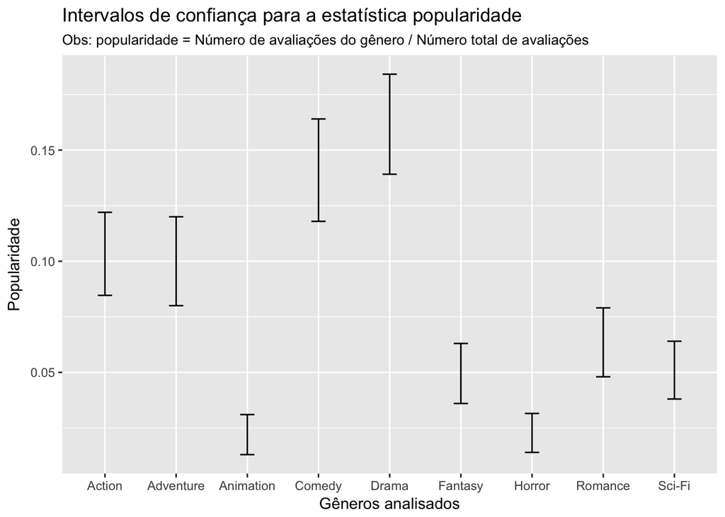

```r
df$medida = rownames(df)
df %>%
  ggplot(aes(x = genres, ymin = X2.5., ymax = X97.5.)) +
  geom_errorbar(width = .2) +
    labs(title = "Intervalos de confiança para a estatística popularidade", x = "Gêneros analisados", y = "Popularidade", subtitle = "Obs: popularidade = Número de avaliações do gênero / Número total de avaliações")
```

Com base na visualização acima fica claro que a estatística calculada não é relevante uma vez que, no nível de significância escolhido, não podemos afirmar nada sobre o gênero mais popular, pois temos qus os dois “maiores” intervalos se interceptam (*Comédia* e *Drama*). Caso obtivessemos dados de **TODAS** as análises já realizadas por usuários do movielens(população) qualquer um desses dois gêneros poderia vir a ser o *mais popular*.

### Pergunta 2: Qual o gênero de filme é o melhor?

Para responder essa pergunta, vamos utilizar como estatística a média dos ratings dados pelos usuários para cada gênero. Mias uma vez iremos utilizar a técnica de bootstrap para reamostrar os dados e aproximar sua distribuição amostral da distribuição real da população.

```r
bests = c()

for (genero in genres) {

  best <- function(x, i){
    d = x[i,]
    media = mean((d %>% filter(genre == genero))$rating)
    return(media)
  }

  boot_genre = bootstrap(amostra, best, R = 1000)
  best_genre = CI.percentile(boot_genre, c = probs(.025, .975))
  bests = rbind(bests, best_genre)
}
```

Novamente, com o o bootstrap realizado já podemos gerar os intervalos de confiança para a média dos ratings e verificar qual o *melhor* filme:

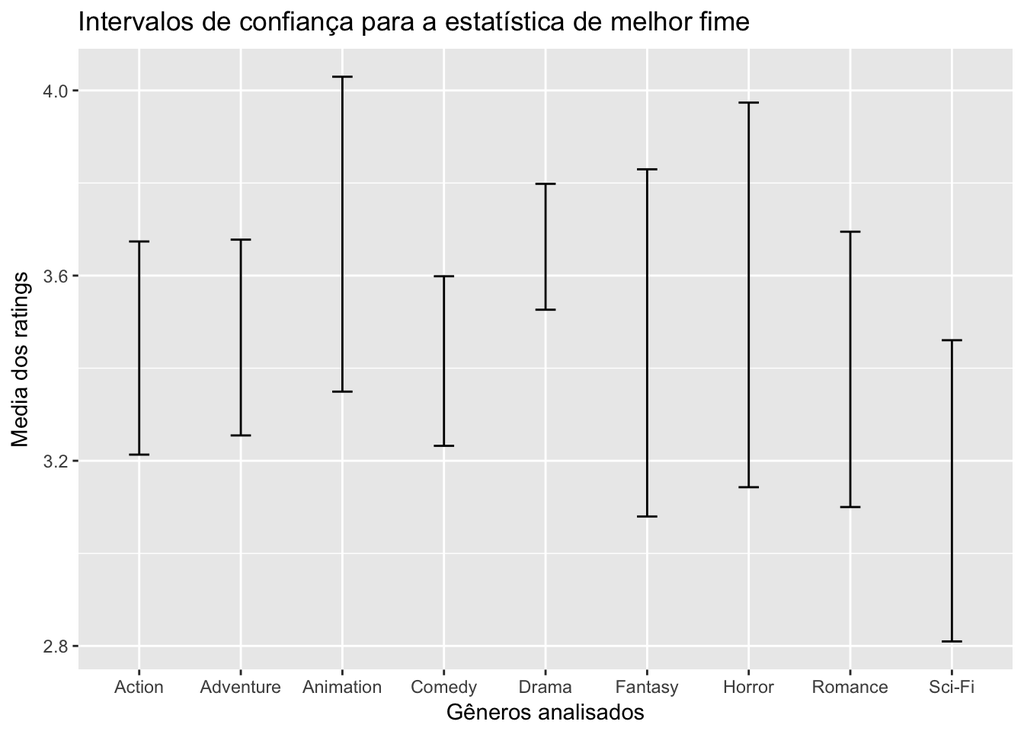

```r
df = data.frame(rbind(bests))
df$medida = rownames(df)
df %>%
  ggplot(aes(x = genres, ymin = X2.5., ymax = X97.5.)) +
  geom_errorbar(width = .2) +
    labs(title = "Intervalos de confiança para a estatística de melhor fime", x = "Gêneros analisados", y = "Media dos ratings")
```

## Teste de hipótese

Agora responderemos a nossa segunda pergunta utilizando a técnica de teste de hipótese e estimação de p-valor, e iremos comparar com os resultados obtidos via intervalo de confiança. Assim como com intervalos de confiança, a estatítica que utilizaremos é a media.

Com base no que observamos nos intervalos de confiança nossa hipótese é que **existe uma diferença significativa** entre as médias dos ratings dos gêneros aqui analisados (Drama e Comédia). Vamos realizar um teste de permutação e observar o resultado que obtemos.

```r
amostra = sample_n(dados, 100000) %>% filter(genre %in% c("Comedy", "Drama")) %>% group_by(genre)

permutationTest2(data = amostra, statistic = mean(rating), treatment = genre)
```

```
## Call:
## permutationTest2(data = amostra, statistic = mean(rating), treatment = genre)
## Replications: 9999
## Two samples, sample sizes are 14295 16763
##
## Summary Statistics for the difference between samples 1 and 2:
##                              Observed          Mean Alternative PValue
## mean(rating): Comedy-Drama -0.2345909 -3.473495e-05   two.sided  2e-04
```

## Conclusões obtidas

Nesse caso, **a hipótese nula é que não existe uma diferença significativa**. Contudo, como obtivemos um **p-valor <= 0.5** podemos **rejeitar** a hipótese nula e **num nível de significância de 1% podemos afirmar que existe uma diferença significativa** entre as médias dos dois gêneros.

### Sobre p-valor

O p-valor funciona como uma probabilidade, a probabilidade de que, dado que a hipótese nula é verdadeira, sejam obtidos valores semelhantes àquele que foi observado. Se obtivermos um p-valor muito alto teríamos muitos valores semelhantes ao que foi observado inicialmente **num mundo em que a hipótese nula é verdadeira!** Ou seja não seria possível relacionar o valor observado com a nossa hipótese uma vez que muitos valores semelhantes acontecem até mesmo num mundo em que a hipótese contrária a nossa é verdadeira.

### Sobre intervalos de confiança e Testes de Hipótese

*Intervalos de confiança:* São ótimos para estimar a magnitude alguma estatística, no nosso caso a média. Não muito útil para testar afirmações pontuais.

*Testes de hipótese:* São ótimos para aceitar/rejeitar alguma afirmação pontual, no nosso caso a afirmação de que existe diferença entre as médias.